# GSC Batch 3: Sequence Statistics

Nikita Telkar

August 20, 2021

### 0.0 Introduction

Here, I’m going to perform standard EDA on the Batch 3 data (both cell-sorted and whole villi). I’m only going to use miRNAs for all statistics, uness specified.

### 1.0 Loading files and packages

```r
library(tidyverse)
library(here)
library(readxl)
library(openxlsx)
library(arsenal)
library(pheatmap)
library(knitr)
library(rmarkdown)
library(data.table)
library(gridExtra)
library(scales)
```

```r
library(showtext)
library(extrafont)

font_paths("C:/Users/nikita.telkar/AppData/Local/Microsoft/Windows/Fonts")
```

```
## [1] "C:\\Users\\nikita.telkar\\AppData\\Local\\Microsoft\\Windows\\Fonts"
## [2] "C:\\Windows\\Fonts"
```

```r
font_add("Montserrat", regular = "Montserrat-Regular.ttf")

showtext_auto()

my_theme <- theme_minimal() + theme(plot.title = element_text(family = "Montserrat", size = 14),
    plot.subtitle = element_text(family = "Montserrat", size = 12), legend.text = element_text(family = "Montserrat",
        size = 10), axis.title = element_text(family = "Montserrat", size = 14))

colpal <- list(Titration = c(`250` = "#003f5c", `100` = "#444e86", `50` = "#955196", `25` = "#dd5182",
    `5` = "#ff6e54", `1` = "#ffa600"), Conc = c(`10` = "#00cfe3", `50` = "#003f5c"), Trimester = c(First = "#8bab48",
    Term = "#488f31"), Extraction = c(TRIzol = "#de425b", miRVana = "#009900"), Cell_type = c(Trophoblast = "#5ab33d",
    Stromal = "#ffb708", Endothelial = "#f95d6a", Hofbauer = "#0075ab", Villi = "#b30000"),
    PM = c(PM384 = "#f2c080", PM385 = "#496076"), DNased = c(Yes = "#67c392", No = "#969695"))
```

```r
eDat <- readRDS(file = here::here("Batch_3", "data", "processed", "eDat.RDS"))
pDat <- readRDS(file = here::here("Batch_3", "data", "processed", "pDat.RDS"))
mDat <- readRDS(file = here::here("Batch_3", "data", "processed", "mDat.RDS"))
all <- readRDS(file = here::here("Batch_3", "data", "processed", "all_sncRNA.RDS"))

eDat_Batch2 <- read_excel("Z:/Nikita/Projects/titration/data/external/overview_run_n_w_hrtp-cs_test_all_250-1_test_1/quantification_raw.xlsx")
pDat_Batch2 <- read_excel(here::here("Batch_3", "data", "processed", "pDat_Batch2.xlsx"))
mDat_Batch2 <- readRDS("Z:/Nikita/Projects/titration/data/processed/mDat_GSC_1790.rds")

# pDat containing only PL290 and TCR Samples
pDat_Batch3 <- read_excel(here::here("Batch_3", "data", "processed", "pDat_Batch3.xlsx"))
```

```r
#splitting all Batch 3 by sncRNA
all_list <- all %>%
 split(f = as.factor(.$sncRNA))
sncRNA_order <- names(all_list)

#making Sample Column
pDat_Batch2 <- pDat_Batch2 %>%
  mutate(v = case_when(
    Case_ID == "PL290" ~ "PL290",
    Case_ID == "TCR-2-18_v_SNAP" ~ "TCR"
  ))

pDat_Batch2 <- pDat_Batch2 %>%
 unite("Sample", c("v", "Titration"), sep = "_", remove = FALSE)
pDat_Batch2 <- pDat_Batch2[-c(12)]


#keeping only PL290 and TCR 250 - 5 ng samples
eDat_Batch2 <- eDat_Batch2 %>%
 unite("Reference", 1:2, sep = "_", remove = TRUE)
eDat_Batch2 <- eDat_Batch2[c(1:13)]
names(eDat_Batch2)
```

```
##  [1] "Reference"
##  [2] "m19817_1_CGATGT_75bp_4_lanes.merge_chastity_passed"
##  [3] "m19818_1_TTAGGC_75bp_4_lanes.merge_chastity_passed"
##  [4] "m19819_1_TGACCA_75bp_4_lanes.merge_chastity_passed"
##  [5] "m19820_1_ACAGTG_75bp_4_lanes.merge_chastity_passed"
##  [6] "m19821_1_GCCAAT_75bp_4_lanes.merge_chastity_passed"
##  [7] "m19822_1_CAGATC_75bp_4_lanes.merge_chastity_passed"
##  [8] "m19825_1_TAGCTT_75bp_4_lanes.merge_chastity_passed"
##  [9] "m19826_1_GGCTAC_75bp_4_lanes.merge_chastity_passed"
## [10] "m19827_1_CTTGTA_75bp_4_lanes.merge_chastity_passed"
## [11] "m19828_1_AAACAT_75bp_4_lanes.merge_chastity_passed"
## [12] "m19829_1_AAAGCA_75bp_4_lanes.merge_chastity_passed"
## [13] "m19830_1_AAATGC_75bp_4_lanes.merge_chastity_passed"
```

```r
colnames(eDat_Batch2) [2:13] <- pDat_Batch2$Sample


#subsetting only PL290 and TCR expression columns from Batch 3
eDat_Batch3 <- all[c(1,2,23:28)]
eDat_Batch3 <- eDat_Batch3 %>%
  filter(sncRNA == "miRNA") %>%
  dplyr::select(-sncRNA)


#funnily enough, the total number of miRNAs mapped for Batch 2 and Batch 3 were the same


#making PL290 and TCR Batch 2 and 3 samples eDat
eDat_conc <- eDat_Batch2 %>%
  inner_join(eDat_Batch3, by = "Reference")

#matching column order of pDat2 to pDat3
pDat_Batch2 <- pDat_Batch2[names(pDat_Batch3)]

#making PL290 and TCR Batch 2 and 3 samples pDat
pDat_conc <- rbind(pDat_Batch2, pDat_Batch3)
glimpse(pDat_conc)
```

```
## Rows: 18
## Columns: 11
## $ RobLab_ID  <chr> "PL290_v_RNAlater", "PL290_v_RNAlater", "PL290_v_RNAlater",~
## $ Sample     <chr> "PL290_250", "PL290_100", "PL290_50", "PL290_25", "PL290_5"~
## $ GSC_ID     <chr> "m19817", "m19818", "m19819", "m19820", "m19821", "m19822",~
## $ Case_ID    <chr> "PL290", "PL290", "PL290", "PL290", "PL290", "PL290", "TCR-~
## $ GSC_Batch  <dbl> 2, 2, 2, 2, 2, 2, 2, 2, 2, 2, 2, 2, 3, 3, 3, 3, 3, 3
## $ Titration  <dbl> 250, 100, 50, 25, 5, 1, 250, 100, 50, 25, 5, 1, 50, 50, 50,~
## $ Trimester  <chr> "First", "First", "First", "First", "First", "First", "Term~
## $ Sex        <chr> "Female", "Female", "Female", "Female", "Female", "Female",~
## $ DNased     <chr> NA, NA, NA, NA, NA, NA, NA, NA, NA, NA, NA, NA, "Yes", "Yes~
## $ Extraction <chr> "TRIzol", "TRIzol", "TRIzol", "TRIzol", "TRIzol", "TRIzol",~
## $ Beads      <chr> "Steel", "Steel", "Steel", "Steel", "Steel", "Steel", "Stee~
```

```r
pDat_conc$Titration <- as.factor(pDat_conc$Titration)
pDat_conc$Extraction <- as.factor(pDat_conc$Extraction)
pDat_conc$Beads <- as.factor(pDat_conc$Beads)
pDat_conc$GSC_Batch <- as.factor(pDat_conc$GSC_Batch)

eDat_conc <- eDat_conc %>%
  column_to_rownames(var = "Reference")

#for easier reference later on
colnames(eDat_conc)[13:14] <- c("PL290_50_2", "TCR_50_2")

all(colnames(eDat_conc) == pDat_conc$Sample)
```

```
## [1] TRUE
```

```r
#Making pDat and eDat for PM384 and PM385

pDat_PMs <- mDat[27:30,]
pDat_PMs <- rbind(pDat_PMs, mDat[20,])
pDat_PMs <- pDat_PMs %>%#chnaging order of rows
  slice(3,1,4,2,5)
eDat_PMs <- all[c(1,2,31,29,32,30,22)]
# eDat_PMs <- eDat %>%
#   dplyr::select(which(names(eDat) %in% pDat_PMs$Sample))
eDat_PMs <- eDat_PMs %>%
 split(f = as.factor(.$sncRNA))
```

### 2.0 Cell-Sorted Samples

#### 2.1 Summary on Sequences / Reads QC

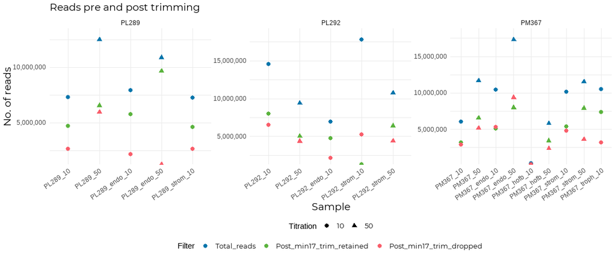

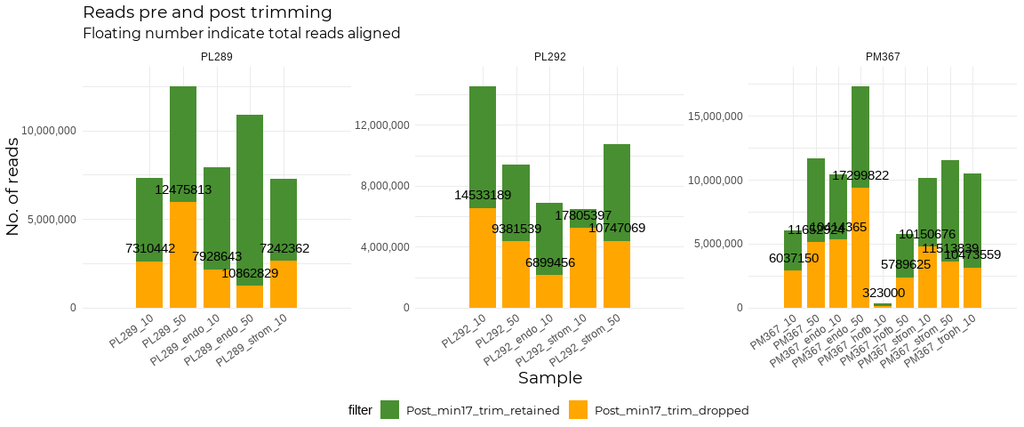

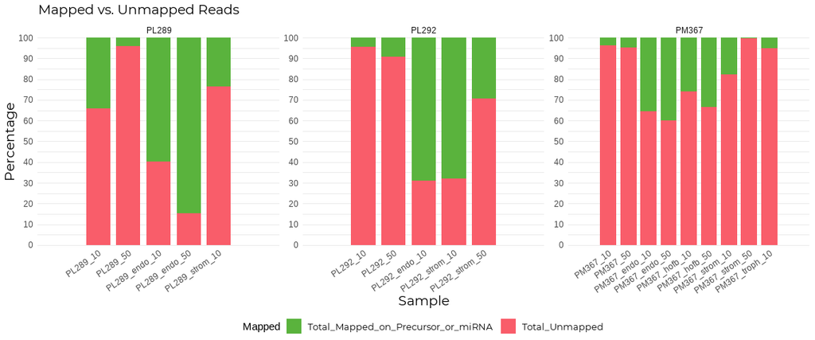

> The GSC has already advised that 30-50% of the reads covered are true miRNAs, so the higher percentage figure seen for unmapped reads make sense.

#### 2.2 Read Filtering

##### Total Reads for all sncRNAs for all cell-sorted samples

```
## # A tibble: 6 x 10
##   Sample        RobLab_ID Case_ID GSC_RNAconc_ng_~ Titration Titrated Sample_type
##   <chr>         <chr>     <chr>              <dbl> <fct>     <chr>    <chr>
## 1 PL289_endo_10 PL289_en~ PL289                  5 10        yes      Cells
## 2 PL289_endo_10 PL289_en~ PL289                  5 10        yes      Cells
## 3 PL289_endo_10 PL289_en~ PL289                  5 10        yes      Cells
## 4 PL289_endo_10 PL289_en~ PL289                  5 10        yes      Cells
## 5 PL289_endo_10 PL289_en~ PL289                  5 10        yes      Cells
## 6 PL289_endo_10 PL289_en~ PL289                  5 10        yes      Cells
## # ... with 3 more variables: Cell_type <chr>, sncRNA <chr>, reads <dbl>
```

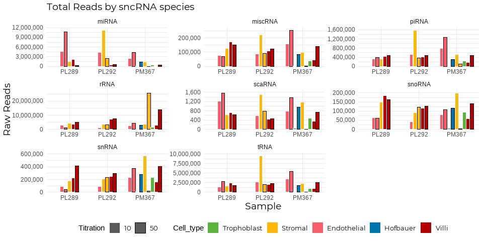

##### Total miRNA Reads for all cell-sorted samples

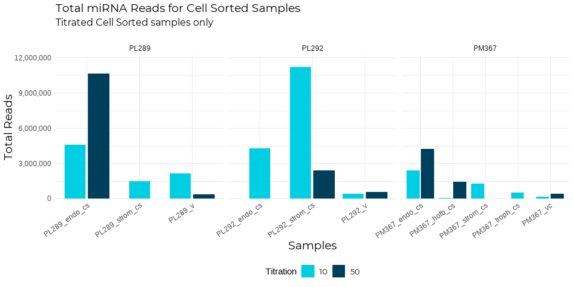

#### 2.3 Species Filtering

I’m going to now count the number of miRNA species for each sample which have:

- At least 1 read count for a species
- At at least 10 read counts for a species

```r
miRNA_species <- all_list$miRNA
miRNA_species <- miRNA_species[-c(1, 2)]

# all miRNA species with at least 1 count
miRNA_species_1 <- colSums(miRNA_species != 0)

miRNA_species_1 <- as.data.frame(miRNA_species_1)
miRNA_species_1$miRNA_species_2 <- colSums(miRNA_species >= 2)
miRNA_species_1$miRNA_species_10 <- colSums(miRNA_species >= 10)  #all miRNA species with at least 10 counts

colnames(miRNA_species_1)[1] <- "miRNA_species_1"

miRNA_species <- miRNA_species_1
rm(miRNA_species_1)

miRNA_species <- miRNA_species %>%
    rownames_to_column(var = "Sample")

mDat <- mDat %>%
    inner_join(miRNA_species, by = "Sample")

miRNA_species %>%
    kable()
```

[output not shown]

```r
# function to get dimensions of a list
f1 <- function(x) {
    list(dim = dim(x))
}


cs_list <- all[c(1:21)]

cs_list <- cs_list %>%
    split(f = as.factor(.$sncRNA))

dim_all <- lapply(cs_list, f1)
dim_all <- as.data.frame(unlist(dim_all))


# only keeping seqs with read count of >= 2
total_species <- map(cs_list, function(x) x %>%
    dplyr::select(-sncRNA) %>%
    filter_all(all_vars(. >= 2)))

# Hmm, looks like none of the scaRNAs passed that minimum 2 filter

total_species <- within(total_species, rm(scaRNA))

total_species <- map(total_species, function(x) x %>%
    column_to_rownames(var = "Reference"))

total_species %>%
    map(function(x) x %>%
        min(x))
```

```
## $miRNA
## [1] 2
##
## $miscRNA
## [1] 2
##
## $piRNA
## [1] 2
##
## $rRNA
## [1] 3
##
## $snoRNA
## [1] 2
##
## $snRNA
## [1] 2
##
## $tRNA
## [1] 2
```